# Association Rule Mining and Twitter

# Twitter API Setup

To access a Twitter API you will need to set up an account and receive a consumerKey, the comsumerSecret, the access_Token, and the access_Secret. A popular library and API: “twitteR”.

Once you have your keys, you can set up the API.

```r
requestURL='https://api.twitter.com/oauth/request_token'
accessURL='https://api.twitter.com/oauth/access_token'
authURL='https://api.twitter.com/oauth/authorize'

### NOTES: rtweet is another excellent option
## https://mkearney.github.io/blog/2017/06/01/intro-to-rtweet/
### https://rtweet.info/

### Install the needed packages...
#install.packages("twitteR")
#install.packages("ROAuth")
# install.packages("rtweet")
library(arules)
library(rtweet)
library(twitteR)
library(ROAuth)
library(jsonlite)
#install.packages("streamR")
#library(streamR)
#install.packages("rjson")
library(rjson)
#install.packages("tokenizers")
library(tokenizers)
library(tidyverse)
library(plyr)
```

```r
library(dplyr)
library(ggplot2)
#install.packages("syuzhet")  ## sentiment analysis
library(syuzhet)
library(stringr)
#install.packages("arulesViz")
library(arulesViz)
```

# Collecting Tweets

Next we will set up the API and search for a particular hash tag. We will store the tweets with the designated hash in a csv file for safe keeping. Here, we choose “#Trump” in hopes to get a 100 tweets easily.

```r
##############  Using twittR ##########################################################
setup_twitter_oauth(consumerKey,consumerSecret,access_Token,access_Secret)
```

```
## [1] "Using direct authentication"
```

```r
Search<-twitteR::searchTwitter("#Trump",n=100,since="2018-09-09")
Search_DF <- twListToDF(Search)
TransactionTweetsFile = "Choc.csv"
Search_DF$text[1]
```

```
## [1] "RT @FreddyBernal: Excelente encuentro de trabajo con el Pdte. del Comité de Asuntos Exteriores del Consejo de la Federación Rusa, Konstanti…"
```

```r
## Start the file
Trans <- file(TransactionTweetsFile)
## Tokenize to words
Tokens<-tokenizers::tokenize_words(Search_DF$text[1],stopwords = stopwords::stopwords("en"),
          lowercase = TRUE,  strip_punct = TRUE, strip_numeric = TRUE,simplify = TRUE)
## Write squished tokens
cat(unlist(str_squish(Tokens)), "\n", file=Trans, sep=",")
close(Trans)

## Append remaining lists of tokens into file
## Recall - a list of tokens is the set of words from a Tweet
Trans <- file(TransactionTweetsFile, open = "a")
for(i in 2:nrow(Search_DF)){
  Tokens<-tokenize_words(Search_DF$text[i],stopwords = stopwords::stopwords("en"),
            lowercase = TRUE,  strip_punct = TRUE, simplify = TRUE)
  cat(unlist(str_squish(Tokens)), "\n", file=Trans, sep=",")
}
close(Trans)
```

# Tweets as Transactions

In this section we will read in the tweets stored in the CSV file using the (Association Rule Mining) ARM library. Each tweet will be considered a basket of words. We can use ARM to determine associations of words in tweets.

```r
######### Read in the tweet transactions
TweetTrans <- read.transactions(TransactionTweetsFile,
                                rm.duplicates = FALSE,
                                format = "basket",
                                sep=","
                                ## cols =
                                )
inspect(head(TweetTrans))
```

```
##     items
## [1] {asuntos,
##      comité,
##      con,
##      consejo,
##      de,
##      del,
##      el,
##      encuentro,
##      excelente,
##      exteriores,
##      federación,
##      freddybernal,
##      konstanti,
##      la,
##      pdte,
##      rt,
##      rusa,
##      trabajo}
## [2] {amp,
##      attempt,
##      disagreed,
##      evjpxpwj0l,
##      fool,
##      https,
##      jordan,
##      king,
##      make,
##      oelosi,
##      pelosi,
##      sided,
##      t.co,
##      trump,
##      went}
## [3] {deserve,
##      impeachment,
##      office,
##      opinion,
##      please,
##      pollsofpolitics,
```

[output cut: 41 more lines]

```
##      x0tmynacya}
## [6] {also,
##      china,
##      companies,
##      countries,
##      developing,
##      leaders,
##      met,
##      mog7546,
##      owned,
##      rt,
##      saudiarabia,
##      southkorea,
##      state,
##      three}
```

```r
## See the words that occur the most
Sample_Trans <- sample(TweetTrans, 50)
summary(Sample_Trans)
```

```
## transactions as itemMatrix in sparse format with
##  50 rows (elements/itemsets/transactions) and
##  675 columns (items) and a density of 0.02198519
##
## most frequent items:
##        rt     trump     https      t.co amjoyshow   (Other)
##        42        31        15        15        10       629
##
## element (itemset/transaction) length distribution:
## sizes
##  6  9 11 12 14 15 16 17 18 19 20 21 22
##  1  2  2  5 15  7  6  3  4  1  2  1  1
##
##    Min. 1st Qu.  Median    Mean 3rd Qu.    Max.
##    6.00   14.00   14.50   14.84   16.00   22.00
##
## includes extended item information - examples:
##       labels
## 1        000
## 2         10
## 3 1loa3ixzto
```

```r
## Read the transactions data into a dataframe
TweetDF <- read.csv(TransactionTweetsFile, header = FALSE, sep = ",")
head(TweetDF)
```

```
##       V1              V2        V3              V4      V5          V6
## 1     rt    freddybernal excelente       encuentro      de     trabajo
## 2 oelosi            went    jordan         attempt    make        fool
## 3     rt pollsofpolitics   opinion realdonaldtrump deserve impeachment
## 4     rt         wrightr      much           world watched      aghast
## 5    sat               5    simple        citizens    took        epic
## 6     rt         mog7546      also             met leaders       three
##          V7    V8          V9        V10       V11     V12       V13
## 1       con    el        pdte        del    comité      de   asuntos
## 2     trump  king      jordan  disagreed    pelosi     amp     sided
## 3    office potus      please       vote   retweet     spr
## 4      last  week   president      trump shattered  notion  informed
## 5        26    hr        trip      white     house deliver      dear
## 6 countries china saudiarabia southkorea     state   owned companies
##          V14    V15        V16   V17  V18        V19  V20       V21 V22
## 1 exteriores    del    consejo    de   la federación rusa konstanti
## 2      https   t.co evjpxpwj0l
## 3
## 4       sane    u.s    foreign  poli
## 5     donald resign    letters https t.co x0tmynacya
## 6 developing
```

```r
str(TweetDF)
```

```
## 'data.frame':    102 obs. of  22 variables:
##  $ V1 : Factor w/ 18 levels "300.000","bill",..: 11 8 11 11 12 11 11 11 11 11 ...
##  $ V2 : Factor w/ 49 levels "","5","6","aminahekmet",..: 14 45 35 46 2 29 35 5 5 10 ...
##  $ V3 : Factor w/ 55 levels "","10","36","37",..: 20 26 34 31 41 9 34 50 50 8 ...
##  $ V4 : Factor w/ 59 levels "","2020","advances",..: 19 5 38 57 13 31 38 40 40 21 ...
##  $ V5 : Factor w/ 61 levels "","34","35","abbandonare",..: 13 35 15 59 53 32 15 51 51 23 ...
##  $ V6 : Factor w/ 62 levels "","30","aghast",..: 55 22 29 3 21 54 29 47 47 11 ...
##  $ V7 : Factor w/ 62 levels "","26","3","490",..: 12 57 44 41 2 13 44 26 26 28 ...
##  $ V8 : Factor w/ 57 levels "","20","7","announces",..: 19 26 37 55 23 9 37 8 8 50 ...
##  $ V9 : Factor w/ 60 levels "","20th","4",..: 34 26 36 38 55 43 36 18 18 10 ...
##  $ V10: Factor w/ 57 levels "","000","28",..: 11 14 55 50 56 42 55 17 17 39 ...
##  $ V11: Factor w/ 53 levels "","6","admitting",..: 12 36 42 44 25 46 42 26 26 11 ...
##  $ V12: Factor w/ 55 levels "","amp","apparently",..: 9 2 41 29 12 34 41 45 45 6 ...
##  $ V13: Factor w/ 47 levels "","2","amp","anything",..: 5 37 1 20 10 8 1 44 44 6 ...
##  $ V14: Factor w/ 47 levels "","2109","activated",..: 16 17 1 32 13 11 1 45 45 37 ...
##  $ V15: Factor w/ 43 levels "","1loa3ixzto",..: 6 35 1 39 27 1 1 3 3 1 ...
##  $ V16: Factor w/ 29 levels "","aber","annewill",..: 6 11 1 14 19 1 1 1 1 1 ...
##  $ V17: Factor w/ 24 levels "","4","co","coinciden",..: 5 1 1 16 12 1 1 1 1 1 ...
##  $ V18: Factor w/ 18 levels "","anlatsinlar",..: 6 1 1 1 12 1 1 1 1 1 ...
##  $ V19: Factor w/ 10 levels "","argine","comp",..: 5 1 1 1 10 1 1 1 1 1 ...
##  $ V20: Factor w/ 8 levels "","auch","https",..: 7 1 1 1 1 1 1 1 1 1 ...
##  $ V21: Factor w/ 7 levels "","denha","konstanti",..: 3 1 1 1 1 1 1 1 1 1 ...
##  $ V22: Factor w/ 4 levels "","de","https",..: 1 1 1 1 1 1 1 1 1 1 ...
```

## Cleaning the text data

Note that cleaning the text data is very important in text mining applications. Tweets are especially “messy”. We will remove “rt”, “http”, etc and any other strings of no importance.

```r
## Convert all columns to char
TweetDF<-TweetDF %>%
  mutate_all(as.character)
str(TweetDF)
```

```
## 'data.frame':    102 obs. of  22 variables:
##  $ V1 : chr  "rt" "oelosi" "rt" "rt" ...
##  $ V2 : chr  "freddybernal" "went" "pollsofpolitics" "wrightr" ...
##  $ V3 : chr  "excelente" "jordan" "opinion" "much" ...
##  $ V4 : chr  "encuentro" "attempt" "realdonaldtrump" "world" ...
##  $ V5 : chr  "de" "make" "deserve" "watched" ...
##  $ V6 : chr  "trabajo" "fool" "impeachment" "aghast" ...
##  $ V7 : chr  "con" "trump" "office" "last" ...
##  $ V8 : chr  "el" "king" "potus" "week" ...
##  $ V9 : chr  "pdte" "jordan" "please" "president" ...
##  $ V10: chr  "del" "disagreed" "vote" "trump" ...
##  $ V11: chr  "comité" "pelosi" "retweet" "shattered" ...
##  $ V12: chr  "de" "amp" "spr" "notion" ...
##  $ V13: chr  "asuntos" "sided" "" "informed" ...
##  $ V14: chr  "exteriores" "https" "" "sane" ...
##  $ V15: chr  "del" "t.co" "" "u.s" ...
##  $ V16: chr  "consejo" "evjpxpwj0l" "" "foreign" ...
##  $ V17: chr  "de" "" "" "poli" ...
##  $ V18: chr  "la" "" "" "" ...
##  $ V19: chr  "federación" "" "" "" ...
##  $ V20: chr  "rusa" "" "" "" ...
##  $ V21: chr  "konstanti" "" "" "" ...
##  $ V22: chr  "" "" "" "" ...
```

```r
# We can now remove certain words
TweetDF[TweetDF == "t.co"] <- ""
TweetDF[TweetDF == "rt"] <- ""
TweetDF[TweetDF == "http"] <- ""
TweetDF[TweetDF == "https"] <- ""

## Clean with grepl - every row in each column
MyDF<-NULL
for (i in 1:ncol(TweetDF)){
  MyList=c() # each list is a column of logicals ...
  MyList=c(MyList,grepl("[[:digit:]]", TweetDF[[i]]))
  MyDF<-cbind(MyDF,MyList)  ## create a logical DF
  ## TRUE is when a cell has a word that contains digits
}
## For all TRUE, replace with blank
TweetDF[MyDF] <- ""
head(TweetDF,10)
```

```
##        V1              V2         V3              V4       V5          V6
## 1            freddybernal  excelente       encuentro       de     trabajo
## 2  oelosi            went     jordan         attempt     make        fool
## 3         pollsofpolitics    opinion realdonaldtrump  deserve impeachment
## 4                 wrightr       much           world  watched      aghast
## 5     sat                     simple        citizens     took        epic
## 6                               also             met  leaders       three
## 7         pollsofpolitics    opinion realdonaldtrump  deserve impeachment
## 8               amjoyshow      trump         release      tax     returns
## 9               amjoyshow      trump         release      tax     returns
## 10             chanelrion adamschiff       falsified evidence       cited
##           V7        V8          V9        V10       V11        V12
## 1        con        el        pdte        del    comité         de
## 2      trump      king      jordan  disagreed    pelosi        amp
## 3     office     potus      please       vote   retweet        spr
## 4       last      week   president      trump shattered     notion
## 5                   hr        trip      white     house    deliver
## 6  countries     china saudiarabia southkorea     state      owned
## 7     office     potus      please       vote   retweet        spr
## 8        end   charges      family enrichment
## 9        end   charges      family enrichment
## 10      fake testimony   consulted    russian comedians bamboozled
##          V13        V14       V15     V16  V17 V18        V19  V20
## 1    asuntos exteriores       del consejo   de  la federación rusa
## 2      sided
## 3
## 4   informed       sane       u.s foreign poli
## 5       dear     donald    resign letters
## 6  companies developing
## 7
## 8                   via amjoyshow
## 9                   via amjoyshow
## 10 believing         th
##          V21 V22
## 1  konstanti
## 2
## 3
## 4
## 5
## 6
## 7
## 8
## 9
## 10
```

```r
# Now we save the dataframe using the write table command
write.table(TweetDF, file = "UpdatedChocolate.csv", col.names = FALSE,
            row.names = FALSE, sep = ",")
TweetTrans <- read.transactions("UpdatedChocolate.csv", sep =",",
            format("basket"),  rm.duplicates = TRUE)
```

```
## distribution of transactions with duplicates:
## items
##  1  2  3  4  6
## 35  3  4  1  1
```

```r
inspect(head(TweetTrans))
```

```
##     items
## [1] {asuntos,
##      comité,
##      con,
##      consejo,
##      de,
##      del,
##      el,
##      encuentro,
##      excelente,
##      exteriores,
##      federación,
##      freddybernal,
##      konstanti,
##      la,
##      pdte,
##      rusa,
##      trabajo}
## [2] {amp,
##      attempt,
##      disagreed,
##      fool,
##      jordan,
##      king,
##      make,
##      oelosi,
##      pelosi,
##      sided,
##      trump,
##      went}
## [3] {deserve,
##      impeachment,
##      office,
##      opinion,
##      please,
##      pollsofpolitics,
##      potus,
##      realdonaldtrump,
##      retweet,
##      spr,
```

[output cut: 28 more lines]

```
##      took,
##      trip,
##      white}
## [6] {also,
##      china,
##      companies,
##      countries,
##      developing,
##      leaders,
##      met,
##      owned,
##      saudiarabia,
##      southkorea,
##      state,
##      three}
```

# ARM

Next we will apply the apriori algorithm to find the associations including computing the support, confidence and lift. Read more on the arules library to tweak / tune the following code to achieve desired results.

```r
# So that you do not have an enormous amount of rules, you can thresholds for
# support, confidence and lift ... also minlength for the rules.
TweetTrans_rules = arules::apriori(TweetTrans,
            parameter = list(support=.025, confidence=.75, minlen=3))
```

```
## Apriori
##
## Parameter specification:
##  confidence minval smax arem  aval originalSupport maxtime support minlen
##        0.75    0.1    1 none FALSE            TRUE       5   0.025      3
##  maxlen target   ext
##      10  rules FALSE
##
## Algorithmic control:
##  filter tree heap memopt load sort verbose
##     0.1 TRUE TRUE  FALSE TRUE    2    TRUE
##
## Absolute minimum support count: 2
##
## set item appearances ...[0 item(s)] done [0.00s].
## set transactions ...[640 item(s), 102 transaction(s)] done [0.00s].
## sorting and recoding items ... [84 item(s)] done [0.00s].
## creating transaction tree ... done [0.00s].
## checking subsets of size 1 2 3 4 5 6 7 8 9 10 done [0.01s].
## writing ... [201668 rule(s)] done [0.05s].
## creating S4 object  ... done [0.09s].
```

```r
inspect(head(TweetTrans_rules))
```

```
##     lhs                              rhs               support
## [1] {gopleader,starknightz}       => {realdonaldtrump} 0.02941176
## [2] {gopleader,realdonaldtrump}   => {starknightz}     0.02941176
## [3] {realdonaldtrump,starknightz} => {gopleader}       0.02941176
## [4] {qanon,starknightz}           => {trump}           0.02941176
## [5] {qanon,trump}                 => {starknightz}     0.02941176
## [6] {starknightz,trump}           => {qanon}           0.02941176
##     confidence lift      count
## [1] 1           6.375000 3
## [2] 1          12.750000 3
## [3] 1          34.000000 3
## [4] 1           1.672131 3
## [5] 1          12.750000 3
## [6] 1          34.000000 3
```

```r
## sorted
SortedRules_conf <- sort(TweetTrans_rules, by="confidence", decreasing=TRUE)
inspect(head(SortedRules_conf))
```

```
##     lhs                              rhs               support
## [1] {gopleader,starknightz}       => {realdonaldtrump} 0.02941176
## [2] {gopleader,realdonaldtrump}   => {starknightz}     0.02941176
## [3] {realdonaldtrump,starknightz} => {gopleader}       0.02941176
## [4] {qanon,starknightz}           => {trump}           0.02941176
## [5] {qanon,trump}                 => {starknightz}     0.02941176
## [6] {starknightz,trump}           => {qanon}           0.02941176
##     confidence lift      count
## [1] 1           6.375000 3
## [2] 1          12.750000 3
## [3] 1          34.000000 3
## [4] 1           1.672131 3
## [5] 1          12.750000 3
## [6] 1          34.000000 3
```

```r
SortedRules_sup <- sort(TweetTrans_rules, by="support", decreasing=TRUE)
inspect(head(SortedRules_sup))
```

```
##     lhs              rhs       support   confidence lift     count
## [1] {tax,via}     => {returns} 0.1372549 1          7.285714 14
## [2] {returns,via} => {tax}     0.1372549 1          7.285714 14
## [3] {returns,tax} => {via}     0.1372549 1          7.285714 14
## [4] {tax,via}     => {release} 0.1372549 1          7.285714 14
## [5] {release,via} => {tax}     0.1372549 1          7.285714 14
## [6] {release,tax} => {via}     0.1372549 1          7.285714 14
```

# Displaying Results

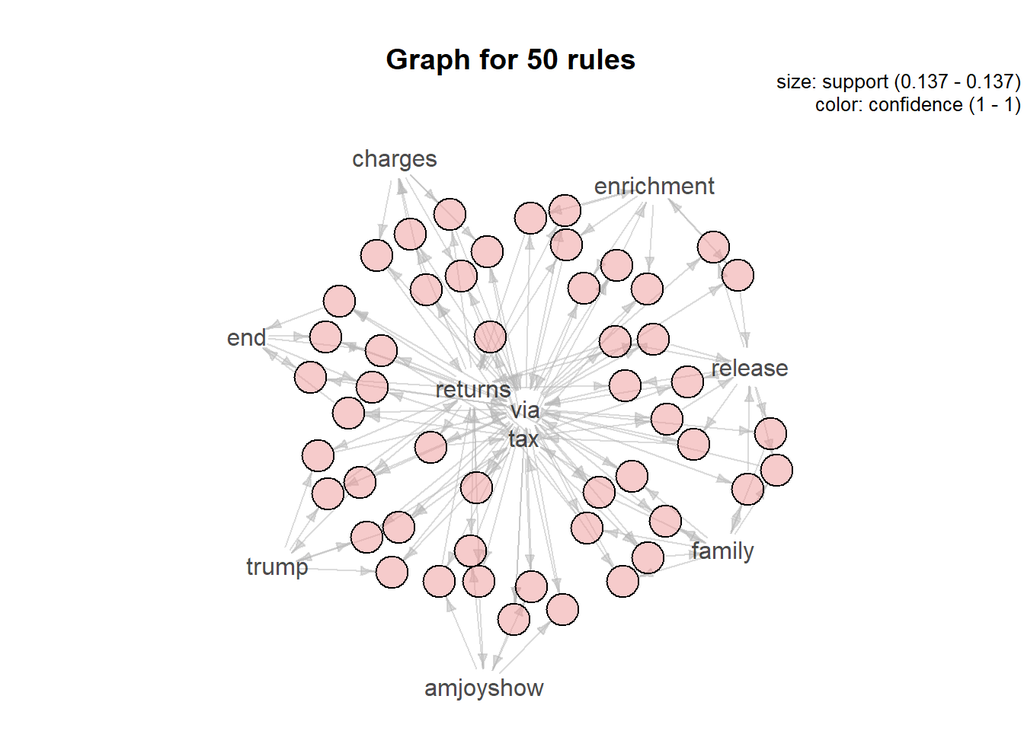

```r
plot (SortedRules_sup[1:50],method="graph",shading="confidence")
```

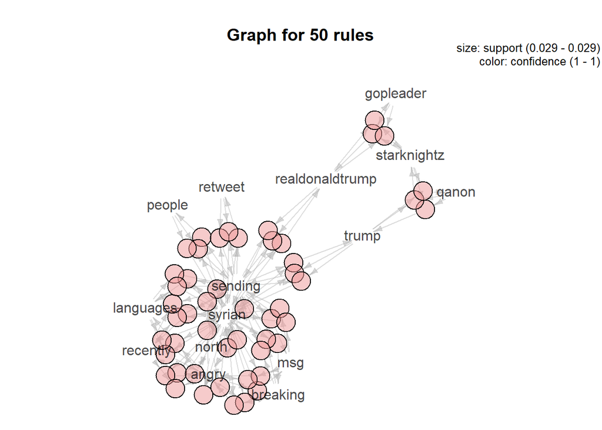

```r
plot (SortedRules_conf[1:50],method="graph",shading="confidence")
```

```r
#plot (SortedRules_sup[1:50],method="graph",interactive=TRUE,shading="confidence")
#plot (SortedRules_conf[1:50],method="graph",interactive=TRUE,shading="confidence")
```